# Introducción a R

Emily Cherrez

2023-07-06

# INTRODUCCIÓN A R

Se revisará los fundamentos de R

## Vectores

```r
dormirH <- c(8, 6, 4, 3, 5, 10)
nombres <- c("Moises", "Mika", "Dorian", "Ranier",
             "Emily", "Henry")
nombres[4]
```

```
## [1] "Ranier"
```

## Listas

```r
Hdormir = list(nombre = nombres,
               horas = dormirH)
Hdormir$horas[2]
```

```
## [1] 6
```

## DataFrame (tablas)

```r
df_dormir <- data.frame(list(nombre = nombres,
                             horas = dormirH))
df_dormir
```

```
##   nombre horas
## 1 Moises     8
## 2   Mika     6
## 3 Dorian     4
## 4 Ranier     3
## 5  Emily     5
## 6  Henry    10
```

## Leer datos externos

```r
gbtemp <- read.csv("gbtemp.csv",
                   header = TRUE, sep = ",")
head(gbtemp, 3)
```

```
##   STATION_ID    DATE  TIME LATITUDE LONGITUDE YEAR MONTH DAY SEASON MEASUREMENT
## 1      13296 6/20/91 11:04 29.50889 -94.75806 1991     6  20 Summer        28.0
## 2      13296 3/17/92  9:30 29.50889 -94.75806 1992     3  17 Spring        20.1
## 3      13296 9/23/91 11:24 29.50889 -94.75806 1991     9  23   Fall        26.0
```

### Exploración

```r
str(gbtemp)
```

```
## 'data.frame':    15276 obs. of  10 variables:
##  $ STATION_ID : int  13296 13296 13296 13296 13296 13296 13296 13305 13305 13305 ...
##  $ DATE       : chr  "6/20/91" "3/17/92" "9/23/91" "9/23/91" ...
##  $ TIME       : chr  "11:04" "9:30" "11:24" "11:24" ...
##  $ LATITUDE   : num  29.5 29.5 29.5 29.5 29.5 ...
##  $ LONGITUDE  : num  -94.8 -94.8 -94.8 -94.8 -94.8 ...
##  $ YEAR       : int  1991 1992 1991 1991 1991 1991 1992 1987 1987 1987 ...
##  $ MONTH      : int  6 3 9 9 6 12 6 3 4 8 ...
##  $ DAY        : int  20 17 23 23 20 17 29 24 2 11 ...
##  $ SEASON     : chr  "Summer" "Spring" "Fall" "Fall" ...
##  $ MEASUREMENT: num  28 20.1 26 26 28 13 29.2 18.5 16.9 29.8 ...
```

```r
summary(gbtemp)
```

```
##    STATION_ID        DATE               TIME              LATITUDE
##  Min.   :13296   Length:15276       Length:15276       Min.   :29.30
##  1st Qu.:13363   Class :character   Class :character   1st Qu.:29.44
##  Median :14558   Mode  :character   Mode  :character   Median :29.51
##  Mean   :14453                                         Mean   :29.50
##  3rd Qu.:15221                                         3rd Qu.:29.57
##  Max.   :17972                                         Max.   :29.67
##    LONGITUDE           YEAR          MONTH             DAY
##  Min.   :-95.02   Min.   :1969   Min.   : 1.000   Min.   : 1.0
##  1st Qu.:-94.94   1st Qu.:1990   1st Qu.: 3.000   1st Qu.: 8.0
##  Median :-94.89   Median :1998   Median : 6.000   Median :15.0
##  Mean   :-94.89   Mean   :1996   Mean   : 6.371   Mean   :15.2
##  3rd Qu.:-94.84   3rd Qu.:2002   3rd Qu.:10.000   3rd Qu.:23.0
##  Max.   :-94.71   Max.   :2014   Max.   :12.000   Max.   :31.0
##     SEASON           MEASUREMENT
##  Length:15276       Min.   : 3.889
##  Class :character   1st Qu.:16.000
##  Mode  :character   Median :22.000
##                     Mean   :21.656
##                     3rd Qu.:28.000
##                     Max.   :35.800
```

## Análisis

### Comparación (prueba de hipótesis)

$H_0: \mu_w = \mu_su = \mu_sp = \mu_f$ No existe diferencia en las medidas asociado a la temporada.

$H_a: \mu_w \neq \mu_su \neq \mu_sp \neq \mu_f$ Al menos una de las estaciones presenta una medida diferente.

```r
gbtemp$SEASON <- as.factor(gbtemp$SEASON)

library(dplyr)
gbtemp %>% group_by(SEASON) %>%
  summarise(mean_meas = mean(MEASUREMENT))
```

```
## # A tibble: 4 x 2
##   SEASON mean_meas
##   <fct>      <dbl>
## 1 Fall        22.1
## 2 Spring      21.7
## 3 Summer      29.6
## 4 Winter      13.7
```

### Análisis de varianzas (aov, ANOVA)

```r
summary(aov(MEASUREMENT ~ SEASON, data = gbtemp))
```

```
##                Df Sum Sq Mean Sq F value Pr(>F)
## SEASON          3 493517  164506   14151 <2e-16 ***
## Residuals   15272 177543      12
## ---
## Signif. codes:  0 '***' 0.001 '**' 0.01 '*' 0.05 '.' 0.1 ' ' 1
```

Con una confianza del 95% existe diferencia de la medida en al menos una de las estaciones.

#### Análisis posterior (del ANOVA)

```r
aov_gbtemp <- aov(MEASUREMENT ~ SEASON, data = gbtemp)
TukeyHSD(aov_gbtemp, "SEASON", inherits = TRUE)
```

```
##   Tukey multiple comparisons of means
##     95% family-wise confidence level
##
## Fit: aov(formula = MEASUREMENT ~ SEASON, data = gbtemp)
##
## $SEASON
##                      diff         lwr         upr   p adj
## Spring-Fall    -0.3938433  -0.5971817  -0.1905049 3.9e-06
## Summer-Fall     7.5280173   7.3209277   7.7351069 0.0e+00
## Winter-Fall    -8.3828599  -8.5871171  -8.1786026 0.0e+00
## Summer-Spring   7.9218606   7.7241838   8.1195374 0.0e+00
## Winter-Spring  -7.9890166  -8.1837242  -7.7943090 0.0e+00
## Winter-Summer -15.9108772 -16.1094991 -15.7122553 0.0e+00
```

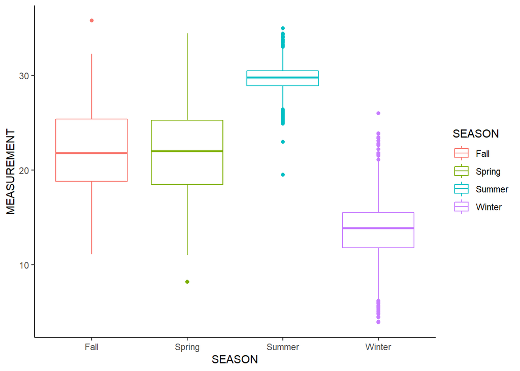

```r
library(ggplot2)
gbtemp %>% ggplot(aes(x= SEASON, y = MEASUREMENT, color = SEASON)) +
  geom_boxplot() + theme_classic()
```

Análisis de regresión (efectos) H0:β1=0 No hay cambio del largo del sépalo debido al ancho del sépalo.

Ha:β1≠0 Existe cambio del largo del sépalo debido al ancho del sépalo.

```r
irislm = lm(Sepal.Length ~ Sepal.Width, data = iris)
summary(irislm)
```

```
##
## Call:
## lm(formula = Sepal.Length ~ Sepal.Width, data = iris)
##
## Residuals:
##     Min      1Q  Median      3Q     Max
## -1.5561 -0.6333 -0.1120  0.5579  2.2226
##
## Coefficients:
##             Estimate Std. Error t value Pr(>|t|)
## (Intercept)   6.5262     0.4789   13.63   <2e-16 ***
## Sepal.Width  -0.2234     0.1551   -1.44    0.152
## ---
## Signif. codes:  0 '***' 0.001 '**' 0.01 '*' 0.05 '.' 0.1 ' ' 1
##
## Residual standard error: 0.8251 on 148 degrees of freedom
## Multiple R-squared:  0.01382,    Adjusted R-squared:  0.007159
## F-statistic: 2.074 on 1 and 148 DF,  p-value: 0.1519
```

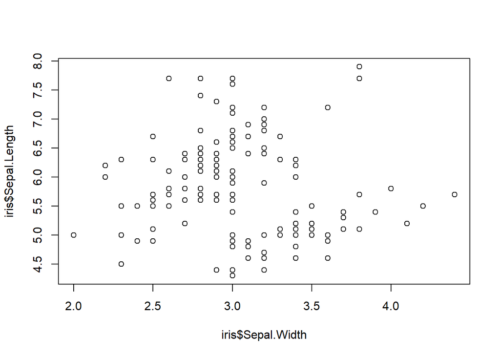

```r
plot( x= iris$Sepal.Width, y = iris$Sepal.Length)
```

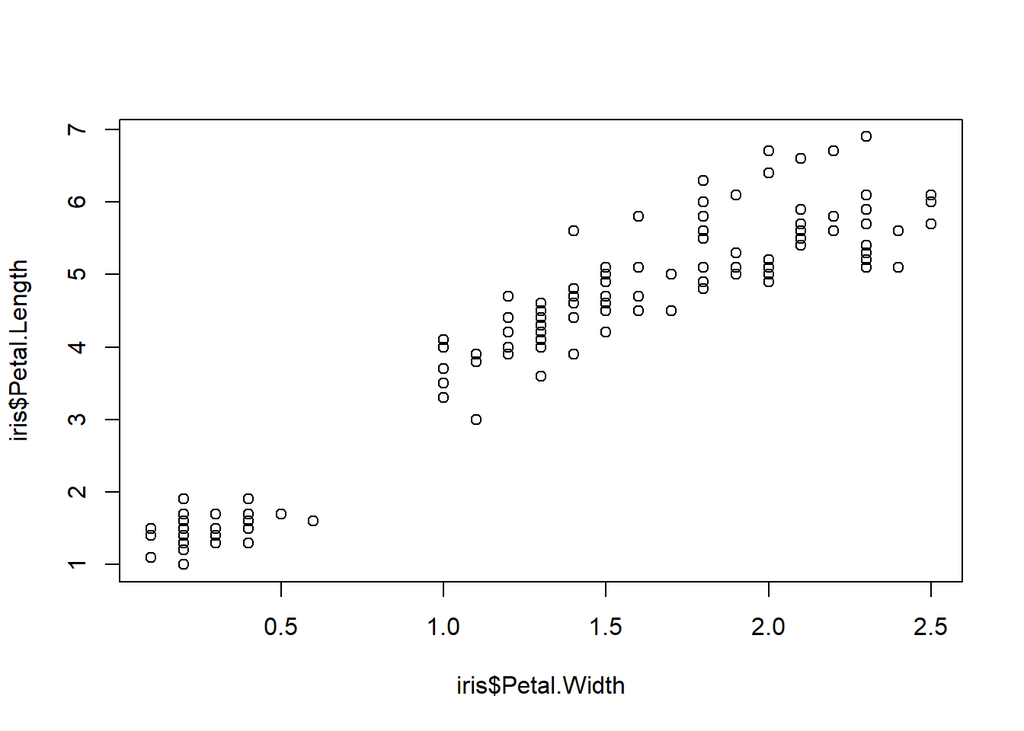

```r
plot( x= iris$Petal.Width, y = iris$Petal.Length)
```

```r
irislm = lm(Petal.Length ~ Petal.Width, data = iris)
summary(irislm)
```

```
##
## Call:
## lm(formula = Petal.Length ~ Petal.Width, data = iris)
##
## Residuals:
##      Min       1Q   Median       3Q      Max
## -1.33542 -0.30347 -0.02955  0.25776  1.39453
##
## Coefficients:
##             Estimate Std. Error t value Pr(>|t|)
## (Intercept)  1.08356    0.07297   14.85   <2e-16 ***
## Petal.Width  2.22994    0.05140   43.39   <2e-16 ***
## ---
## Signif. codes:  0 '***' 0.001 '**' 0.01 '*' 0.05 '.' 0.1 ' ' 1
##
## Residual standard error: 0.4782 on 148 degrees of freedom
## Multiple R-squared:  0.9271, Adjusted R-squared:  0.9266
## F-statistic:  1882 on 1 and 148 DF,  p-value: < 2.2e-16
```

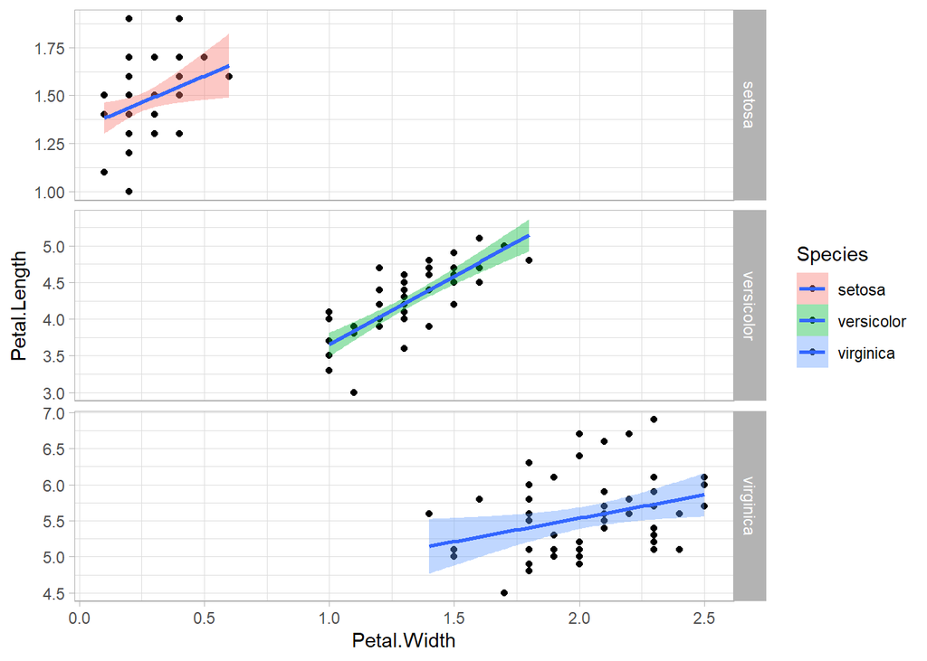

```r
library(ggplot2)
iris %>%  ggplot(aes(x= Petal.Width, y = Petal.Length, fill = Species)) +
  geom_point() + geom_smooth(method = "lm") + theme_light() +
  facet_grid(Species ~ ., scales = "free" )
```

$$PL = 1.08 + 2.22 \cdot PW +
\epsilon$$

########################Actividad#########################################3

Replica de la regresion lineal en la data de palmer penguins. hacer una regresion lineal de la data.

```r
library(palmerpenguins)
```

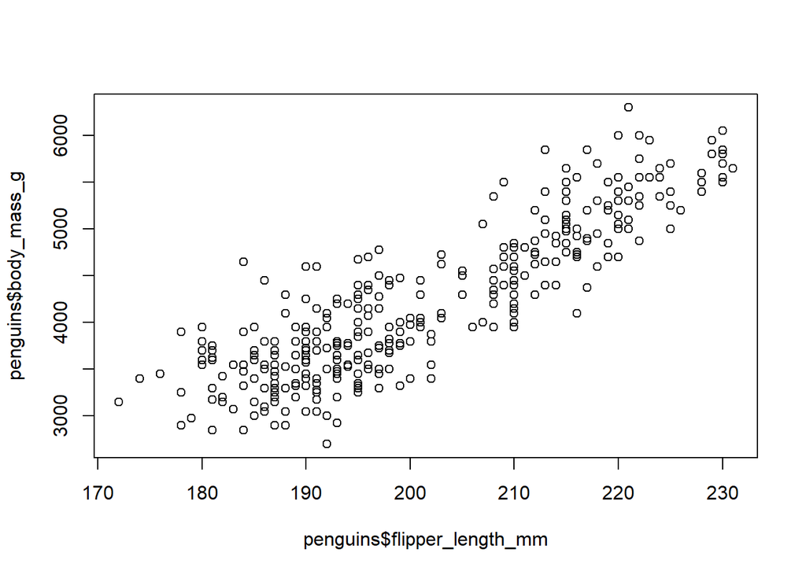

```r
plot(x = penguins$flipper_length_mm, y = penguins$body_mass_g)
```

```r
penguinslm <- lm(flipper_length_mm ~ body_mass_g, data = penguins)
summary(penguinslm)
```

```
##
## Call:
## lm(formula = flipper_length_mm ~ body_mass_g, data = penguins)
##
## Residuals:
##      Min       1Q   Median       3Q      Max
## -23.7626  -4.9138   0.9891   5.1166  16.6392
##
## Coefficients:
##              Estimate Std. Error t value Pr(>|t|)
## (Intercept) 1.367e+02  1.997e+00   68.47   <2e-16 ***
## body_mass_g 1.528e-02  4.668e-04   32.72   <2e-16 ***
## ---
## Signif. codes:  0 '***' 0.001 '**' 0.01 '*' 0.05 '.' 0.1 ' ' 1
##
## Residual standard error: 6.913 on 340 degrees of freedom
##   (2 observations deleted due to missingness)
## Multiple R-squared:  0.759,  Adjusted R-squared:  0.7583
## F-statistic:  1071 on 1 and 340 DF,  p-value: < 2.2e-16
```